# Nothing to Lose

Teenagers Who Never Held the Vote Declined as Much as Those Who Lost It

Author

Affiliation

Linlin Feng

Shenzhen College of International Education

Abstract

German states set the voting age for their own elections, while the federal voting age is eighteen. Therefore, some teenagers in Schleswig-Holstein in 2017 could vote in the May state election but not the September federal election. Leininger et al. found that their external efficacy declined and interpreted this as harm from losing the vote. Yet they both lost a previously held right and were excluded from an election. This paper asks whether the decline reflected withdrawal or exclusion. Using the original authors’ published panel survey of 3,897 teenagers, I first re-estimated their comparison between teenagers who lost the vote and those who kept it. I then made their appendix comparison with teenagers who had never been eligible the centre of the analysis. Difference-in-differences models compared each teenager with themselves over time and then compared these changes across groups. External efficacy declined by 0.208 points among teenagers who lost the vote relative to those who kept it, while the corresponding decline among teenagers who had never been eligible was 0.182 points. The estimated lost-versus-never difference was −0.026 points, with a 95 per cent confidence interval from −0.157 to +0.106. This interval rules out an additional withdrawal effect as large as my estimated lost-versus-kept decline, although it remains consistent with smaller effects. Because the never-eligible teenagers were younger and there was only one pre-election wave, age-related differences cannot be ruled out. The similar declines leave exclusion as a possible explanation, while the uncertainty prevents a conclusion that withdrawal has no effect. Studies of rights withdrawal should compare people who lose a right with people who never held it and interpret uncertain estimates through confidence intervals.

```r
# 1. Load the tools used below.
# dplyr organises rows; ggplot2 draws figures; fixest fits panel models; knitr prints tables.
library(dplyr)
library(ggplot2)
library(fixest)
library(knitr)

# 2. Read the survey: each row is one teenager answering one survey wave.
# ext_eff means external efficacy; demsat means satisfaction with democracy.
# id identifies the teenager; status identifies their voting group.
# The |> symbol passes the result of one step into the next.
survey_data <- read.csv("data/panel.csv")

# 3. Keep the first two waves for teenagers who answered both.
# filter selects rows; mutate adds post, which is 0 before the election and 1 after.
panel_sample <- survey_data |>
  filter(wave %in% c(1, 2), in_w2 == 1) |>
  mutate(post = as.integer(wave == 2))

# Count teenagers once, even though each answers twice.
# na.rm = TRUE leaves out missing answers when calculating averages.
number_of_panel_teenagers <- n_distinct(panel_sample$id)
number_of_wave1_teenagers <- n_distinct(survey_data$id[survey_data$wave == 1])
city_percentage <- 100 * mean(panel_sample$kreisfrei[panel_sample$wave == 1], na.rm = TRUE)


# 4. Select complete efficacy pairs, then compare changes across groups.
# group_by(id) gathers each teenager's answers; all() requires both answers to be present.
# is.na() identifies missing answers; ! means "not". ungroup() removes the grouping.
efficacy_sample <- panel_sample |>
  group_by(id) |>
  filter(all(!is.na(ext_eff))) |>
  ungroup()

# In feols(), the outcome is left of ~; i(status, post) compares each group's change.
# ref = "kept" makes teenagers who kept eligibility the comparison group.
# After |, id allows each teenager a different starting level; wave absorbs shared changes.
# These fixed effects do not remove age-related differences in how attitudes change.
# cluster = ~id allows the same teenager's two answers to be related when measuring uncertainty.
efficacy_model_kept_reference  <- feols(ext_eff ~ i(status, post, ref = "kept")  | id + wave,
                 cluster = ~id, data = efficacy_sample)
efficacy_model_never_reference <- feols(ext_eff ~ i(status, post, ref = "never") | id + wave,
                 cluster = ~id, data = efficacy_sample)

# 5. Save the estimates and their uncertainty.
# coef() returns estimates; se() returns their standard errors.
# "status::lost:post" selects the lost group's change relative to the reference group.
# A coefficient table has four columns: estimate, standard error, t statistic, p-value.
# Negative estimates mean a larger decline than in the comparison group.
# Adding and subtracting 1.96 standard errors gives an approximate 95% confidence interval.
efficacy_lost_vs_kept   <- coef(efficacy_model_kept_reference)["status::lost:post"]
efficacy_lost_vs_kept_standard_error <- se(efficacy_model_kept_reference)["status::lost:post"]
efficacy_never_vs_kept  <- coef(efficacy_model_kept_reference)["status::never:post"]
efficacy_never_vs_kept_standard_error <- se(efficacy_model_kept_reference)["status::never:post"]
efficacy_lost_vs_never    <- coef(efficacy_model_never_reference)["status::lost:post"]
efficacy_lost_vs_never_standard_error <- se(efficacy_model_never_reference)["status::lost:post"]
efficacy_lost_vs_never_lower_limit <- efficacy_lost_vs_never - 1.96 * efficacy_lost_vs_never_standard_error
efficacy_lost_vs_never_upper_limit <- efficacy_lost_vs_never + 1.96 * efficacy_lost_vs_never_standard_error
efficacy_lost_vs_never_p_value  <- summary(efficacy_model_never_reference)$coeftable["status::lost:post", 4]

shared_decline_percentage <- 100 * efficacy_never_vs_kept / efficacy_lost_vs_kept   # share of the decline the never group also shows

# 6. Calculate descriptive averages using all available answers in each group and wave.
# This sample can differ from the complete pairs used by the efficacy model.
# The standard error and confidence limits show uncertainty around each average.
# These averages are used in both figures below.
efficacy_means_by_group <- panel_sample |>
  filter(!is.na(ext_eff)) |>
  group_by(status, wave) |>
  summarise(
    mean_efficacy = mean(ext_eff),
    standard_error = sd(ext_eff) / sqrt(n()),
    lower_limit = mean_efficacy - 1.96 * standard_error,
    upper_limit = mean_efficacy + 1.96 * standard_error,
    .groups = "drop"
  )

efficacy_means_kept_and_lost <- efficacy_means_by_group |>
  filter(status != "never")

# 7. Repeat the analysis for satisfaction, requiring two usable satisfaction answers.
# Its complete pairs differ from efficacy because the missing answers differ.
satisfaction_sample <- panel_sample |>
  group_by(id) |>
  filter(all(!is.na(demsat))) |>
  ungroup()
satisfaction_model_kept_reference <- feols(demsat ~ i(status, post, ref = "kept") | id + wave,
                    cluster = ~id, data = satisfaction_sample)
satisfaction_model_never_reference <- feols(demsat ~ i(status, post, ref = "never") | id + wave,
                     cluster = ~id, data = satisfaction_sample)

# coef() selects the estimate; se() selects its standard error.
# In coeftable, column 4 is the p-value for that comparison.
satisfaction_lost_vs_kept <- coef(satisfaction_model_kept_reference)["status::lost:post"]
satisfaction_lost_vs_kept_standard_error <- se(satisfaction_model_kept_reference)["status::lost:post"]
satisfaction_lost_vs_kept_p_value <- summary(satisfaction_model_kept_reference)$coeftable["status::lost:post", 4]
satisfaction_never_vs_kept <- coef(satisfaction_model_kept_reference)["status::never:post"]
satisfaction_never_vs_kept_standard_error <- se(satisfaction_model_kept_reference)["status::never:post"]
satisfaction_never_vs_kept_p_value <- summary(satisfaction_model_kept_reference)$coeftable["status::never:post", 4]
satisfaction_lost_vs_never <- coef(satisfaction_model_never_reference)["status::lost:post"]
satisfaction_lost_vs_never_standard_error <- se(satisfaction_model_never_reference)["status::lost:post"]
satisfaction_lost_vs_never_p_value <- summary(satisfaction_model_never_reference)$coeftable["status::lost:post", 4]

# 8. Keep the two excluded groups after the federal election to compare anger.
# lost is 1 for those who lost the vote and 0 for those who never had it.
# Convert distance from the birth-date cutoff from days to years.
anger_sample <- survey_data |>
  filter(wave == 2, status %in% c("lost", "never")) |>
  mutate(
    lost = as.integer(status == "lost"),
    years_from_cutoff = days_loss / 365.25
  )

# Fit four anger models: no adjustments, background only, age only, and both.
# Background includes gender, migration background, school track, and city residence.
# Each teenager appears once, so these lm() models use conventional standard errors.
# A + adds an adjustment variable; unlike the panel models, these compare different people.
anger_model_unadjusted <- lm(anger ~ lost, data = anger_sample)
anger_model_background <- lm(anger ~ lost + female + migration + abitur + kreisfrei,
               data = anger_sample)
anger_model_age <- lm(anger ~ lost + years_from_cutoff, data = anger_sample)
anger_model_age_and_background <- lm(
  anger ~ lost + years_from_cutoff + female + migration + abitur + kreisfrei,
  data = anger_sample
)

# In an lm coefficient table, columns 1–4 are estimate, standard error, t statistic and p-value.
anger_unadjusted_difference <- summary(anger_model_unadjusted)$coefficients["lost", 1]
anger_age_adjusted_difference <- summary(anger_model_age)$coefficients["lost", 1]

# 9. Calculate the share of Wave 1 respondents who returned for Wave 2.
# Include those who dropped out so the return rate describes the starting sample.
wave2_response_rate <- survey_data |>
  filter(wave == 1) |>
  summarise(rate = mean(in_w2, na.rm = TRUE)) |>
  pull(rate)

response_sample <- survey_data |>
  filter(wave == 1, status %in% c("kept", "lost")) |>
  mutate(lost = as.integer(status == "lost"))

# Compare the groups' chances of returning.
# The second model checks whether initial efficacy predicts return differently by group.
response_model_group <- lm(in_w2 ~ lost, data = response_sample)
response_model_interaction <- lm(in_w2 ~ lost * ext_eff, data = response_sample)

response_lost_vs_kept <- summary(response_model_group)$coefficients["lost", 1]
response_interaction <- summary(response_model_interaction)$coefficients["lost:ext_eff", 1]
response_interaction_standard_error <- summary(response_model_interaction)$coefficients["lost:ext_eff", 2]
# Column 4 is the p-value; nobs() counts the observations actually used by the model.
response_interaction_p_value <- summary(response_model_interaction)$coefficients["lost:ext_eff", 4]
response_interaction_observations <- nobs(response_model_interaction)


# 10. Compare average birth dates in the two excluded groups, omitting missing dates.
# A later birth date means a younger group; divide the gap in days by 365.25 for years.
birthdates_by_group <- panel_sample |>
  filter(wave == 2, status %in% c("lost", "never")) |>
  mutate(mean_birthdate = as.Date(birthdate)) |>
  filter(!is.na(mean_birthdate)) |>
  group_by(status) |>
  summarise(mean_birthdate = mean(mean_birthdate), .groups = "drop")

birthdate_gap_days  <- as.numeric(birthdates_by_group$mean_birthdate[birthdates_by_group$status == "never"] -
                            birthdates_by_group$mean_birthdate[birthdates_by_group$status == "lost"])
birthdate_gap_years <- birthdate_gap_days / 365.25
```

# 1 Introduction

## Context

Lowering the voting age may influence more than whether young people participate in one election. Parents and schools may help young people take part in their first elections, and early participation may help voting become a habit, as discussed by Franklin 2004 and Leininger et al. 2023. This also raises a broader question: do young people trust political institutions because they possess formal political power, or because they feel that institutions listen to them?

Germany’s federal structure allows voting rights to change across elections. Its sixteen states set the rules for their own state and local elections, while the voting age for federal elections is eighteen under Article 38 of the Basic Law. Schleswig-Holstein therefore allowed sixteen- and seventeen-year-olds to vote in its state election on 7 May 2017, but those still under eighteen could not vote in the federal election on 24 September. The different thresholds created a natural experiment in eligibility across elections, although birth date also determined age and therefore did not make the groups randomly comparable. The state rule remained unchanged, and by the May 2018 local elections all three groups in the survey were eligible again, as described by Leininger et al. 2023.

Leininger et al. 2023 found that teenagers who could vote in May but not September became less likely to believe that politicians listened to people like them. Compared with teenagers who remained eligible, their external political efficacy declined by about 0.19 points on a five-point scale, as reported in their online appendix Table E.1. The authors interpreted this as evidence that losing the vote harmed young people’s political attitudes.

## Research Question

In September 2017, these teenagers experienced two changes at the same time. A federal election took place without them, and a vote they had held in May was no longer available. Comparing them with teenagers who remained eligible combines these experiences: the groups differed both in whether they lost the vote and in whether they could participate in September. It therefore cannot show whether the decline resulted from withdrawal or from being excluded from the election. Would these teenagers look any different if they had never had the vote at all?

## Importance

Suppose the harm comes from being left out of the federal election. Then the teenagers who lost the vote were no worse off than they would have been if Schleswig-Holstein had never lowered its state voting age, because exclusion is the normal position of everyone below the relevant voting age. Suppose instead that the harm comes from losing a right they previously held. Then introducing the vote in stages created an additional harm, suggesting that voting-age reform should cover different levels of elections together. The original authors interpreted their result in the second way, so distinguishing these explanations matters.

## Methods and Data

I first re-estimate the original comparison using the authors’ published panel survey of 3,897 teenagers. I focus on the first two waves and compare each respondent’s answer before and after the federal election.

I then add the teenagers who were too young to vote in either election. As Figure 2 shows, birth dates determine membership in the three groups and also reveal that the never-eligible teenagers were younger than those who lost the vote.

Finally, I compare the changes experienced by the two barred groups. Difference-in-differences asks whether one group changed more than another over the same period, while comparing each teenager only with their own earlier response.

## Findings and Contribution

I recover a similar pattern to the original study: external efficacy declined by 0.208 points among teenagers who lost the vote relative to those who kept it. Teenagers who had never been eligible declined by 0.182 points, leaving a lost-versus-never difference of only −0.026 points. The original study attributed the decline to losing the vote. The similar decline among teenagers who never held it leaves exclusion as another possible explanation. However, because the never-eligible group was about 1.23 years younger, I cannot establish that exclusion caused the change. The two age groups may have developed differently over the four months.

## Structure of the Paper

Section 2 reviews earlier research on political support, youth participation and voting rules. Section 3 develops the exclusion and withdrawal explanations. Section 4 describes the survey, groups and outcomes, while Section 5 explains the comparisons. Section 6 reports the results, Section 7 examines their limitations, and Section 8 summarises the argument and its implications.

# 2 Literature Review

## Political support

The study of political support starts with Easton 1975’s distinction between specific support for the current authorities and diffuse support for the political system as a whole. Norris 2011 also states that it is possible for people to lose confidence in politicians and institutions without rejecting democracy. Employing more rigorous methods than those used in earlier observational studies, Kelly et al. 2026 discover that the link between political trust and participation is weaker than previously believed. The importance of these distinctions lies in the fact that believing that politicians listen is different from believing that democracy works. External efficacy and satisfaction with democracy may thus change in different ways.

## Why young people vote less

A second group of studies examines lower turnout among younger citizens. Franklin 2004 argues that the elections which people take part in when they first become eligible can largely influence their future participation since voting might eventually become a habit. According to Blais and Rubenson 2013, the fact that young people have a lower turnout is due to their weaker political interest and their diminished perception of voting as a civic duty. Smets 2016 demonstrates that both life-cycle and generational changes account for the reason why the difference in turnout between younger and older citizens has increased. Evidence from Austria also separates low turnout from an inability to make an informed choice. Wagner et al. 2012 find that voters under eighteen made choices of similar quality to those of older voters, even though their turnout was relatively low. Their study concerns participation among eligible young people; this paper asks how young people respond when an election excludes them.

Since the first elections can influence later participation, the experience of being allowed to vote and then losing that right may also affect the political attitudes of young people.

## How voting rules shape who votes

A third body of research shows how electoral rules affect participation. Braconnier et al. 2017 show that the amount of effort needed to register stops some eligible citizens from voting. Fowler 2013 finds that compulsory voting in Australia changed who voted, thereby affecting the election results and policy. Leininger et al. 2023 examine teenagers who were eligible for the Schleswig-Holstein state election in May 2017 but ineligible for the September federal election; their sense of external efficacy decreased in comparison to teenagers who remained eligible, a result which the authors see as a consequence of disenfranchisement. The studies mentioned indicate that voting rules can change who takes part in elections and may also influence political attitudes.

## What is missing

Leininger et al. examine young people who lose eligibility across successive elections. Nevertheless, losing the right to vote always occurs alongside exclusion; a teenager who has lost their voting eligibility is also unable to vote in the present election. In Table F.2 of their appendix, the authors compare teenagers who have lost the right to vote with those who have never been eligible at all; they find a small difference of −0.06 points in external efficacy and regard this as broadly in line with their argument although less precise. However, this comparison is given only as one of a number of robustness checks, while their conclusion still attributes the drop to having lost the vote. That is the gap this article addresses.

The paper does not present a new dataset or identify a previously unexamined comparison group since the teenagers who were never eligible were already part of Leininger et al.’s data and appendix. Rather, I make the comparison in the appendix between the lost and the never-eligible groups the main focus of the paper. By using the same teenagers’ responses both before and after the federal election, I compare each respondent with their earlier response and then look at how the responses changed between the two groups. Finally, I interpret the estimate through its confidence interval, distinguishing effects that are inconsistent with the data from smaller effects that the sample remains too imprecise to exclude.

# 3 Theory

## Two explanations

**Exclusion.** Being ineligible to vote may reduce external political efficacy by suggesting that the political system does not yet recognise a teenager as someone whose views should influence an election. This message could affect teenagers regardless of whether they had been eligible before. In September 2017, both teenagers who had lost eligibility since May and younger teenagers who had never been eligible were excluded from the federal election. Therefore, it is possible that both groups would become less likely to think that politicians take young people like them seriously. If exclusion is the main mechanism, external efficacy should decline by about the same amount in both groups.

**Withdrawal.** Teenagers who were eligible for the May state election but still under eighteen in September could not vote in the federal election under Article 38 of the Basic Law. From their point of view, they went from being included to being excluded. I expect this change will be particularly noticeable. Losing voting eligibility may create a stronger feeling of rejection than never having been eligible, because recent inclusion provides a standard against which to judge later exclusion. External efficacy should decrease more among teenagers who lost their eligibility than among those who were ineligible for both elections.

## The test

Comparing the two excluded groups helps distinguish these explanations. Although both groups were excluded in September, only one of them had been eligible during the May state election. Similar declines would fit the exclusion explanation, while a larger decline among those who lost eligibility would fit an additional withdrawal effect. A causal interpretation would still require the groups to have followed similar trends without the difference in eligibility.

## Causal framework

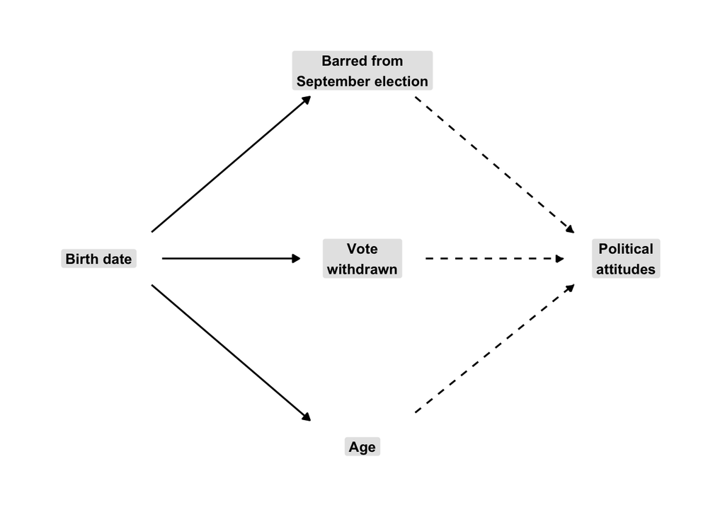

Figure 1: Birth date determines eligibility, withdrawal and age; solid arrows show the links set by birth date and electoral rules; dashed arrows show possible effects of exclusion, withdrawal and age on attitudes.

```r
# Set the positions of the diagram labels.
diagram_labels <- data.frame(
  label = c("Birth date", "Barred from\nSeptember election",
            "Vote\nwithdrawn", "Age", "Political\nattitudes"),
  x = c(0, 1, 1, 1, 2),
  y = c(0, 1, 0, -1, 0)
)

# Set arrow start and end positions. Solid arrows show known links; dashed arrows show proposed effects.
known_relationship_arrows <- data.frame(
  x = c(0.20, 0.24, 0.20),
  y = c(0.14, 0.00, -0.14),
  xend = c(0.80, 0.76, 0.80),
  yend = c(0.86, 0.00, -0.86)
)

proposed_effect_arrows <- data.frame(
  x = c(1.20, 1.24, 1.20),
  y = c(0.86, 0.00, -0.82),
  xend = c(1.80, 1.76, 1.80),
  yend = c(0.14, 0.00, -0.14)
)

# Draw the arrows and labels, and hide the axes.
causal_diagram <- ggplot() +
  geom_segment(
    data = known_relationship_arrows,
    aes(x = x, y = y, xend = xend, yend = yend),
    arrow = grid::arrow(length = grid::unit(0.18, "cm"), type = "closed"),
    linewidth = 0.6
  ) +
  geom_segment(
    data = proposed_effect_arrows,
    aes(x = x, y = y, xend = xend, yend = yend),
    arrow = grid::arrow(length = grid::unit(0.18, "cm"), type = "closed"),
    linewidth = 0.6,
    linetype = "dashed"
  ) +
  geom_label(
    data = diagram_labels,
    aes(x = x, y = y, label = label),
    fill = "grey90",
    linewidth = 0,
    size = 3.5,
    fontface = "bold"
  ) +
  coord_cartesian(xlim = c(-0.25, 2.25), ylim = c(-1.25, 1.25),
                  clip = "off") +
  theme_void()

# Display the chart; the presentation reuses this same figure.
causal_diagram
```

Figure 1 shows how birth date determines whether a teenager was old enough to vote in May and September and therefore whether they kept the vote, lost it, or never had it. Birth date also determines age, which may independently affect how political attitudes change and therefore complicates the comparison between the lost and never groups.

# 4 Data

## The setting and the survey

I used the original survey data from the Harvard Dataverse replication package published by Leininger et al. 2023, DOI: 10.7910/DVN/T5LYWS. The researchers surveyed 3,897 teenagers in Schleswig-Holstein, Germany’s northernmost state. Sixteen- and seventeen-year-olds could vote in the state election on 7 May 2017, whereas the minimum voting age for the federal election on 24 September was eighteen. Wave 1 was conducted following the state election and before the federal election; Wave 2 was conducted after the federal election. Of the original respondents, 1,900 answered both waves. The efficacy model used 1,738 teenagers with usable efficacy answers in both waves, giving 3,476 observations. The satisfaction model used 1,754 teenagers and 3,508 observations because a different set of answers was missing. The published dataset is the original study’s own anonymised deposit: names and addresses were removed. The only available geographical measure records whether a teenager lived in Kiel, Lübeck, Flensburg or Neumünster, the state’s four independent cities. This described 39 per cent of respondents who answered both waves.

## The three groups

The two voting-age rules divided the teenagers into three groups. Table 1 shows whether each group could participate in the May state election and the September federal election.

```r
# Count each teenager once and put the counts in the same order as the table labels.
teenagers_per_group <- panel_sample |> filter(wave == 1) |> count(status)
eligibility_table <- data.frame(
  Group = c("Kept the vote", "Lost the vote", "Never had the vote"),
  `May eligibility` = c("Eligible", "Eligible", "Ineligible"),
  `September eligibility` = c("Eligible", "Ineligible", "Ineligible"),
  Teenagers = teenagers_per_group$n[match(c("kept", "lost", "never"), teenagers_per_group$status)],
  check.names = FALSE
)

kable(eligibility_table)
```

Table 1: The three groups differ in their eligibility for the two elections, and counts refer to teenagers observed in both survey waves: 1900 teenagers and 3800 survey observations before outcome-specific exclusions.

| Group | May eligibility | September eligibility | Teenagers |
| --- | --- | --- | --- |
| Kept the vote | Eligible | Eligible | 581 |
| Lost the vote | Eligible | Ineligible | 916 |
| Never had the vote | Ineligible | Ineligible | 403 |

The first group was eligible in both elections and therefore kept the vote. The second group was eligible in May but was too young for the federal election, so voting eligibility that had been available to them became unavailable in September. The third group was too young for both elections and therefore never held the vote.

Figure 2 shows the birth-date distribution of all 3,897 teenagers who completed Wave 1.

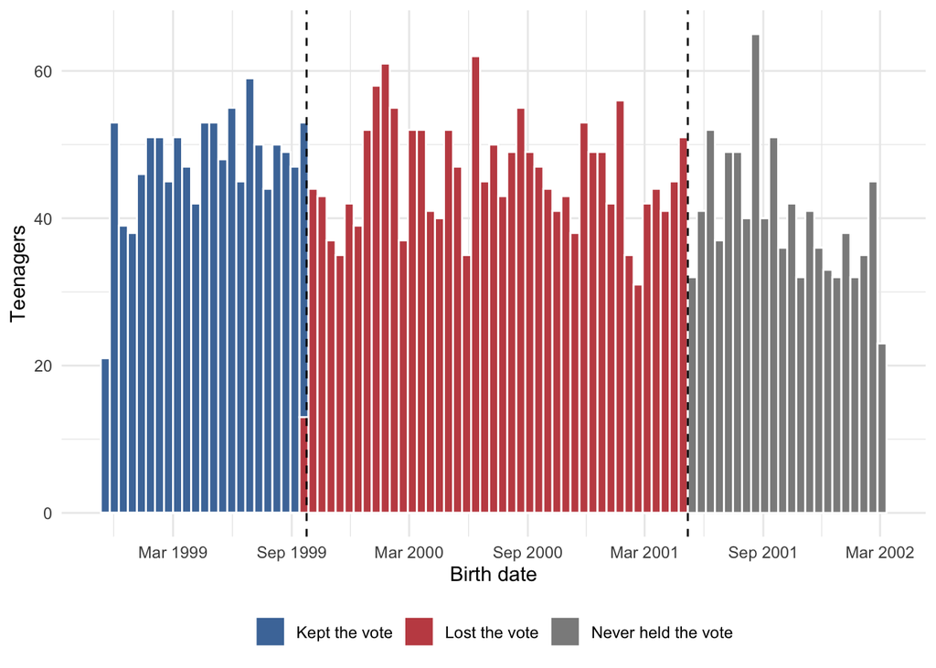

Figure 2: Each bar counts teenagers born within a two-week period among Wave 1 respondents. Colours identify voting groups; dashed lines mark the eligibility cutoffs. A bin edge is fixed at 7 May 2001; a bin crossing the other cutoff contains stacked colours.

```r
# Plot birth dates for all Wave 1 respondents in two-week groups.
# fill = status colours each group; boundary places a bin edge at the May eligibility cutoff.
# Dashed lines mark the two voting-eligibility cutoffs.
wave1_birthdates <- survey_data |> filter(wave == 1) |> mutate(birthdate = as.Date(birthdate))
birthdate_figure <- ggplot(wave1_birthdates, aes(x = birthdate, fill = status)) +
  geom_histogram(binwidth = 14, boundary = as.numeric(as.Date("2001-05-07")), colour = "white") +
  geom_vline(xintercept = as.numeric(as.Date(c("1999-09-24", "2001-05-07"))),
             linetype = "dashed") +
  scale_x_date(date_breaks = "6 months", date_labels = "%b %Y") +
  labs(x = "Birth date", y = "Teenagers") +
  scale_fill_manual(values = c(kept = "#4C78A8", lost = "#C44E52", never = "#8C8C8C"),
                    labels = c(kept = "Kept the vote", lost = "Lost the vote", never = "Never held the vote"),
                    name = NULL) +
  theme_minimal() + theme(legend.position = "bottom")

# Display the chart; the presentation reuses this same figure.
birthdate_figure
```

The group that lost the vote is the largest because its birth-date range covers a longer period than those of the other two groups. At the 7 May 2001 cutoff, the classification changes from teenagers eligible in May to those who were too young, although the birth-date distribution itself remains broadly continuous.

## The outcome

My main outcome was external political efficacy, meaning whether teenagers believe political institutions listen to people like them. In each wave, respondents indicated how strongly they agreed that “Politicians do not care what young people like me think.” Answers ranged from 1, strongly agree, to 5, strongly disagree. Because the statement is negative, a higher score means that the respondent feels more heard. I also examined satisfaction with democracy, measured in every wave on a five-point scale. Finally, the survey asked teenagers after each election how angry they felt about not being permitted to vote. I used the responses collected after the federal election.

# 5 Methods

## The comparisons

I used difference-in-differences to compare how each group’s external efficacy changed between the surveys following the May and September 2017 elections. I compared each respondent with their own earlier answer and then compared these changes across groups. Individual fixed effects accounted for stable personal differences, while wave fixed effects accounted for changes shared by the groups. I clustered the standard errors by respondent because each teenager answered twice and those answers could be related. This allowed for that dependence when estimating uncertainty. The anger and attrition checks used one observation per respondent and conventional standard errors.

I made three comparisons. First, I compared teenagers who lost the vote with those who kept it, re-estimating the original comparison. Second, I compared teenagers who were never eligible with those who kept the vote. Finally, I compared the first two estimates. Both barred groups were excluded from the federal election, but only one had previously been eligible to vote. The difference between their changes estimates an additional withdrawal effect only if their attitudes would otherwise have followed similar trends.

## Reading a null result

I interpreted the final comparison using its estimate and 95 per cent confidence interval. The confidence interval shows the range of effects that remain reasonably consistent with the data. An interval containing zero does not prove that withdrawal had no effect; it may also mean that the sample is too imprecise to detect a smaller effect. As Rainey 2014 explains, a statistically insignificant estimate alone does not establish that an effect is negligible. Following this reasoning, I asked which sizes of withdrawal effect the interval can rule out. I used my estimated lost-versus-kept decline as a comparison point, rather than conducting a formal equivalence test with a pre-specified threshold.

This interpretation depends on the two barred groups having followed similar trends without the change in eligibility. However, the never-eligible teenagers were approximately 1.23 years younger, and only one survey wave preceded the federal election, so I could not check whether the groups were already changing at different rates. Even several earlier waves would not prove that their later counterfactual trends would be parallel. Attrition is another limitation: about 49 per cent of respondents completed Wave 2, and teenagers who lost eligibility were 6.7 percentage points less likely to remain in the survey.

# 6 Findings

## Re-estimating the original comparison

I re-estimated the comparison reported by Leininger et al. 2023. As Figure 3 shows, external efficacy fell among teenagers who lost eligibility relative to those who kept it. My estimated decline of 0.208 points supports the direction of the original association, but differs from the approximately 0.19-point decline reported in their appendix Table E.1. Their group-by-wave model retained available efficacy answers among respondents who attended both waves, even when one efficacy answer was missing. My respondent fixed-effects model used only complete efficacy pairs and compared each teenager with their own earlier answer. These sample and specification differences explain why the estimates need not match exactly.

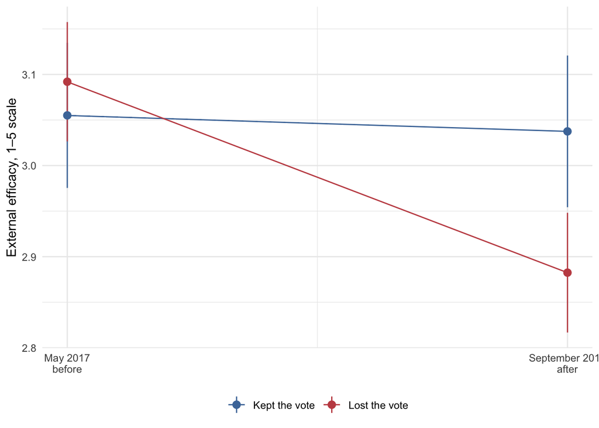

Figure 3: Mean external efficacy in each wave for the teenagers who kept the vote and the teenagers who lost it, with 95 per cent confidence intervals.

```r
# Connect the kept and lost groups' average scores; vertical bars show their 95% confidence intervals.
efficacy_two_groups_figure <- ggplot(efficacy_means_kept_and_lost, aes(x = wave, y = mean_efficacy, colour = status, group = status)) +
  geom_line() +
  geom_pointrange(aes(ymin = lower_limit, ymax = upper_limit)) +
  scale_x_continuous(
    breaks = c(1, 2),
    labels = c("May 2017\nbefore", "September 2017\nafter")
  ) +
  scale_colour_manual(
    values = c(kept = "#4C78A8", lost = "#C44E52", never = "#8C8C8C"),
    labels = c(kept = "Kept the vote", lost = "Lost the vote",
               never = "Never had the vote")
  ) +
  labs(y = "External efficacy, 1–5 scale", x = NULL, colour = NULL) +
  theme_minimal() + theme(legend.position = "bottom")

# Display the chart; the presentation reuses this same figure.
efficacy_two_groups_figure
```

## Adding the group that never had the vote

To examine whether the decline could be attributed specifically to losing eligibility, I included a third group: teenagers who were too young to vote in either election. Figure 4 shows that these teenagers who were excluded in both elections also became less externally efficacious. The decline was 0.182 points relative to those who kept the vote, compared with 0.208 points among those who lost it. Roughly 88 per cent of the decline observed in the lost group therefore also appears among teenagers whose formal political status of exclusion did not change. They had been below the voting-age threshold in both elections.

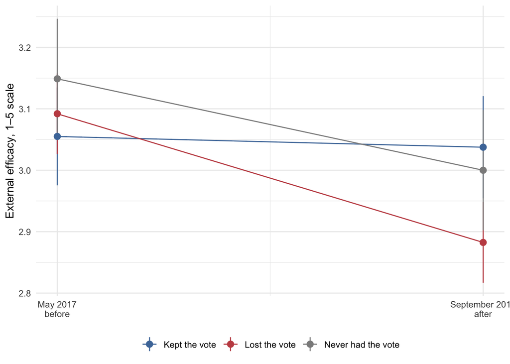

Figure 4: Mean external efficacy in each wave for all three groups, with 95 per cent confidence intervals, showing that the teenagers who never held the vote declined alongside those who lost it.

```r
# Add the never-eligible group, keeping the same labels and colours.
efficacy_three_groups_figure <- ggplot(efficacy_means_by_group, aes(x = wave, y = mean_efficacy, colour = status, group = status)) +
  geom_line() +
  geom_pointrange(aes(ymin = lower_limit, ymax = upper_limit)) +
  scale_x_continuous(
    breaks = c(1, 2),
    labels = c("May 2017\nbefore", "September 2017\nafter")
  ) +
  scale_colour_manual(
    values = c(kept = "#4C78A8", lost = "#C44E52", never = "#8C8C8C"),
    labels = c(kept = "Kept the vote", lost = "Lost the vote",
               never = "Never had the vote")
  ) +
  labs(y = "External efficacy, 1–5 scale", x = NULL, colour = NULL) +
  theme_minimal() + theme(legend.position = "bottom")

# Display the chart; the presentation reuses this same figure.
efficacy_three_groups_figure
```

## The difference between the two groups

The comparison that tests for an additional withdrawal effect compares teenagers who lost voting eligibility with those who had never been eligible. The difference between their declines is −0.026 points. The 95 per cent confidence interval runs from −0.157 to +0.106, with p = 0.703, so the data are consistent both with no additional withdrawal effect and with a smaller effect that the sample is too imprecise to detect. The interval excludes an additional decline as large as my 0.208-point lost-versus-kept estimate, but allows one half that size, so it does not establish whether withdrawal accounts for most of the original decline. This does not prove that the true effect is exactly zero, and Table 2 sets the three estimates side by side.

```r
# Collect the three model comparisons into one table.
# Round displayed numbers only; significance marks use the full-precision p-values.
efficacy_coefficients_kept_reference  <- as.data.frame(summary(efficacy_model_kept_reference)$coeftable)
efficacy_coefficients_never_reference <- as.data.frame(summary(efficacy_model_never_reference)$coeftable)

efficacy_comparison_results <- rbind(
  efficacy_coefficients_kept_reference["status::lost:post", ],
  efficacy_coefficients_kept_reference["status::never:post", ],
  efficacy_coefficients_never_reference["status::lost:post", ]
)

# Columns 1, 2 and 4 contain the estimate, standard error and p-value.
# Stars use the unrounded p-value; a separate row places the SE beneath the estimate.
efficacy_significance <- ifelse(efficacy_comparison_results[, 4] < 0.001, "***",
                       ifelse(efficacy_comparison_results[, 4] < 0.01, "**",
                       ifelse(efficacy_comparison_results[, 4] < 0.05, "*", "")))
efficacy_labels <- c("Lost vs kept: original comparison re-estimated",
                   "Never had the vote vs kept it",
                   "Lost vs never: withdrawal contrast")
efficacy_observations <- rep(nobs(efficacy_model_kept_reference), 3)
efficacy_results_table <- data.frame(
  Comparison = as.vector(rbind(efficacy_labels, "Standard error")),
  Estimate = as.vector(rbind(
    paste0(sprintf("%.3f", efficacy_comparison_results[, 1]), efficacy_significance),
    sprintf("%.3f", efficacy_comparison_results[, 2]))),
  Observations = as.vector(rbind(format(efficacy_observations, big.mark = ","), "")),
  check.names = FALSE
)
efficacy_results_table$Estimate <- gsub("-", "−", efficacy_results_table$Estimate, fixed = TRUE)
kable(efficacy_results_table, align = c("l", "c", "r"))
```

Table 2: The three difference-in-differences estimates for external efficacy are reported with respondent-clustered standard errors beneath estimates.

| Comparison | Estimate | Observations |
| --- | --- | --- |
| Lost vs kept: original comparison re-estimated | −0.208*** | 3,476 |
| Standard error | 0.057 |  |
| Never had the vote vs kept it | −0.182** | 3,476 |
| Standard error | 0.070 |  |
| Lost vs never: withdrawal contrast | −0.026 | 3,476 |
| Standard error | 0.067 |  |

Note: Standard errors appear beneath estimates. * p < 0.05; ** p < 0.01; *** p < 0.001.

Figure 5 displays the same comparisons with their confidence intervals.

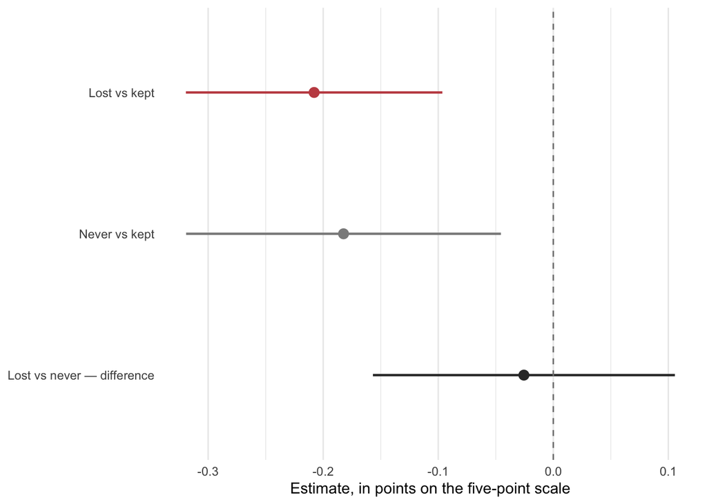

Figure 5: The three external-efficacy estimates are shown with 95 per cent confidence intervals; the dashed vertical line marks an estimate of zero.

```r
# Plot the three estimates with their 95% confidence intervals.
# The vertical line at zero marks no difference between groups.
efficacy_estimates_for_plot <- data.frame(
  comparison = factor(
    c("Lost vs kept", "Never vs kept", "Lost vs never — difference"),
    levels = c("Lost vs never — difference",
               "Never vs kept", "Lost vs kept")
  ),
  estimate = c(efficacy_lost_vs_kept, efficacy_never_vs_kept, efficacy_lost_vs_never),
  standard_error = c(efficacy_lost_vs_kept_standard_error, efficacy_never_vs_kept_standard_error, efficacy_lost_vs_never_standard_error)
)

efficacy_estimates_figure <- ggplot(efficacy_estimates_for_plot,
       aes(x = estimate, y = comparison, colour = comparison)) +
  geom_segment(
    aes(x = estimate - 1.96 * standard_error,
        xend = estimate + 1.96 * standard_error,
        yend = comparison),
    linewidth = 0.8,
    show.legend = FALSE
  ) +
  geom_point(size = 3, show.legend = FALSE) +
  geom_vline(xintercept = 0, linetype = "dashed", colour = "grey50") +
  scale_colour_manual(
    values = c("Lost vs kept" = "#C44E52",
               "Never vs kept" = "#8C8C8C",
               "Lost vs never — difference" = "#333333")
  ) +
  labs(x = "Estimate, in points on the five-point scale", y = NULL) +
  theme_minimal() +
  theme(panel.grid.major.y = element_blank())

# Display the chart; the presentation reuses this same figure.
efficacy_estimates_figure
```

## Other outcomes

Satisfaction with democracy fell significantly among teenagers who lost eligibility relative to those who kept it. The never-versus-kept comparison and the lost-versus-never difference were not statistically significant at the five per cent level. The latter points towards a possible additional withdrawal effect, but remains uncertain. Table 4 reports the estimates in the appendix. I examined this outcome after seeing the main result, so it is an exploratory check.

Teenagers who had lost the right to vote reported 0.424 points more anger than those who had never been eligible. After I accounted for birth date, the estimated difference fell to 0.078 points, suggesting that age may explain much of the raw gap. The full regressions are given in Table 5 in the appendix.

## Summary of findings

The reanalysis recovered a decline in external efficacy among teenagers who lost eligibility relative to those who kept it. Teenagers who were excluded from both elections also declined, by a similar amount. The comparison therefore does not isolate withdrawal as the explanation for the observed decline. Exclusion, age-related development and other differences in how the groups experienced the election remain possible explanations.

# 7 Discussion

## What the results show

My reanalysis recovered the direction of the original association. Teenagers who lost eligibility and teenagers who had never been eligible both became less likely to believe that politicians listened to them. Both groups were excluded from the federal election. Their similar declines leave open the possibility that exclusion mattered even without a previously held vote being withdrawn. This pattern does not establish that exclusion caused the decline, and the confidence interval still allows a smaller additional withdrawal effect.

Satisfaction with democracy points towards a larger decline among teenagers who lost eligibility than among those who had never been eligible. I do not treat this as firm evidence of withdrawal: the difference is not significant at the five per cent level, the check followed the main analysis, and satisfaction was one of several outcomes examined.

## What the results do not show

The first limitation is age. Teenagers in the never-eligible group were, on average, 1.23 years younger than those who lost the vote. Comparing each teenager with their own earlier response accounts for differences that remain stable over time, such as one group beginning with higher efficacy. It does not account for the possibility that fifteen-year-olds and sixteen-year-olds change differently over the same four months. In a longitudinal study, Eckstein et al. 2012 find that political engagement attitudes and willingness to participate develop during adolescence, with different patterns across school tracks. They examine different outcomes, but their findings give a reason to question whether teenagers of different ages would necessarily follow the same trend here. The anger analysis demonstrates why this matters: a large initial difference between the groups almost disappeared after birth date was taken into account. With only one survey wave before the federal election, I can identify this limitation but cannot solve it using these data.

Attrition leads to the second limitation: only about 49 per cent of the original respondents answered the second survey, and teenagers who had lost the vote were 6.7 percentage points less likely to remain. As a result, the teenagers who are included in my analysis are not an exact representation of those who started the survey. Those with higher levels of initial efficacy were generally more likely to remain, though this relationship did not differ in a statistically significant way between the groups that kept the vote and those that lost it. The interaction test is reported in Table 6.

Finally, the paper does not say whether it is a good idea to lower the voting age; instead it focuses on the more specific question of whether teenagers respond differently when they lose a vote they had previously held as compared to when they have never been eligible.

## What would change the answer

A series of surveys carried out before the election would enable researchers to determine if the lost and never groups were already changing along similar paths. Moreover, evidence from another region where voting rights changed in stages would also indicate whether this pattern applies beyond Schleswig-Holstein.

# 8 Conclusion

## Restating the argument

In May 2017, some teenagers in Schleswig-Holstein could vote in the state election but were too young to vote in the federal election in September. The original study found that their external efficacy declined relative to teenagers who remained eligible and interpreted this as a consequence of disenfranchisement. I recover that pattern, but then compare these teenagers with those who were excluded from both elections. Because both barred groups declined by almost the same amount, the evidence does not show that losing a previously held vote by itself explains the original decline. However, the never-eligible group was younger, so I cannot prove that exclusion itself caused the shared decline. The age difference does not solve the original study’s problem: comparing the lost group only with teenagers who kept the vote still cannot show that withdrawal caused the decline.

## Contribution

The original authors had already compared the lost and never-eligible groups in an appendix, but treated this as one of the robustness checks. I make that comparison central, compare each teenager with their own earlier response, and use the confidence interval to show which possible withdrawal effects the data can and cannot rule out.

## Broader implications

To understand the harm of losing a right, compare people who lost it with people who never held it. For policy, the results caution against attributing the full decline to the withdrawal of eligibility. They also give a reason to examine how exclusion affects teenagers who have never been eligible.

## Unresolved questions

Could losing the vote have a smaller effect that this survey was not precise enough to detect?

Would the suggestive decline in satisfaction with democracy appear again in other data?

Do younger teenagers’ political attitudes change over several months differently from those of older teenagers?

# References

Blais, André, and Daniel Rubenson. 2013. “The Source of Turnout Decline: New Values or New Contexts?” *Comparative Political Studies* 46 1: 95–117. https://doi.org/10.1177/0010414012453032.

Braconnier, Céline, Jean-Yves Dormagen, and Vincent Pons. 2017. “Voter Registration Costs and Disenfranchisement: Experimental Evidence from France.” *American Political Science Review* 111 3: 584–604. https://doi.org/10.1017/S000305541700003X.

Easton, David. 1975. “A Re-Assessment of the Concept of Political Support.” *British Journal of Political Science* 5 4: 435–57. https://doi.org/10.1017/S0007123400008309.

Eckstein, Katharina, Peter Noack, and Burkhard Gniewosz. 2012. “Attitudes Toward Political Engagement and Willingness to Participate in Politics: Trajectories Throughout Adolescence.” *Journal of Adolescence* 35 3: 485–95. https://doi.org/10.1016/j.adolescence.2011.07.002.

Fowler, Anthony. 2013. “Electoral and Policy Consequences of Voter Turnout: Evidence from Compulsory Voting in Australia.” *Quarterly Journal of Political Science* 8 2: 159–82. https://doi.org/10.1561/100.00012055.

Franklin, Mark N. 2004. *Voter Turnout and the Dynamics of Electoral Competition in Established Democracies Since 1945*. Cambridge University Press. https://doi.org/10.1017/CBO9780511616884.

Kelly, Edmund, James Tilley, and Sven Oskarsson. 2026. “Revisiting the Link Between Political Trust and Political Participation.” *The Journal of Politics* 88 3: 1048–65. https://doi.org/10.1086/736338.

Leininger, Arndt, Marie-Lou Sohnius, Thorsten Faas, Sigrid Roßteutscher, and Armin Schäfer. 2023. “Temporary Disenfranchisement: Negative Side Effects of Lowering the Voting Age.” *American Political Science Review* 117 1: 355–61. https://doi.org/10.1017/S000305542200034X.

Norris, Pippa. 2011. *Democratic Deficit: Critical Citizens Revisited*. Cambridge University Press.

Rainey, Carlisle. 2014. “Arguing for a Negligible Effect.” *American Journal of Political Science* 58 4: 1083–91. https://doi.org/10.1111/ajps.12102.

Smets, Kaat. 2016. “Revisiting the Political Life-Cycle Model: Later Maturation and Turnout Decline Among Young Adults.” *European Political Science Review* 8 2: 225–49. https://doi.org/10.1017/S1755773914000460.

Wagner, Markus, David Johann, and Sylvia Kritzinger. 2012. “Voting at 16: Turnout and the Quality of Vote Choice.” *Electoral Studies* 31 2: 372–83. https://doi.org/10.1016/j.electstud.2012.01.007.

# Appendix

## Summary statistics

Table 3 compares the three groups at Wave 1, before the federal election.

```r
# Calculate Wave 1 averages for each voting group in the panel sample.
# Background variables coded 0 or 1 give proportions; missing answers are omitted.
baseline_means_by_group <- panel_sample |>
  filter(wave == 1) |>
  group_by(status) |>
  summarise(
    teenagers = n(),
    ext_eff = mean(ext_eff, na.rm = TRUE),
    demsat = mean(demsat, na.rm = TRUE),
    female = mean(female, na.rm = TRUE),
    abitur = mean(abitur, na.rm = TRUE),
    migration = mean(migration, na.rm = TRUE),
    kreisfrei = mean(kreisfrei, na.rm = TRUE),
    at_home = mean(at_home, na.rm = TRUE),
    .groups = "drop"
  ) |>
  arrange(match(status, c("kept", "lost", "never")))

# Put each group in its own column, with the teenager count followed by the averages.
baseline_summary_table <- data.frame(
  Measure = c("Teenagers", "External efficacy",
              "Satisfaction with democracy", "Female",
              "Abitur track", "Migration background",
              "Lives in an independent city", "Lives at home"),
  `Kept the vote` = c(
    format(baseline_means_by_group$teenagers[1], scientific = FALSE),
    sprintf("%.2f", unlist(baseline_means_by_group[1, 3:9], use.names = FALSE))
  ),
  `Lost the vote` = c(
    format(baseline_means_by_group$teenagers[2], scientific = FALSE),
    sprintf("%.2f", unlist(baseline_means_by_group[2, 3:9], use.names = FALSE))
  ),
  `Never had the vote` = c(
    format(baseline_means_by_group$teenagers[3], scientific = FALSE),
    sprintf("%.2f", unlist(baseline_means_by_group[3, 3:9], use.names = FALSE))
  ),
  check.names = FALSE
)


kable(baseline_summary_table, align = c("l", "c", "c", "c"))
```

Table 3: At baseline, the three groups differed in external efficacy and several background characteristics; entries are counts or group means from 1900 baseline observations. Means omit missing answers separately for each variable.

| Measure | Kept the vote | Lost the vote | Never had the vote |
| --- | --- | --- | --- |
| Teenagers | 581 | 916 | 403 |
| External efficacy | 3.06 | 3.09 | 3.15 |
| Satisfaction with democracy | 3.73 | 3.74 | 3.78 |
| Female | 0.55 | 0.52 | 0.49 |
| Abitur track | 0.83 | 0.81 | 0.83 |
| Migration background | 0.18 | 0.20 | 0.20 |
| Lives in an independent city | 0.39 | 0.42 | 0.35 |
| Lives at home | 0.93 | 0.98 | 0.98 |

## Satisfaction with democracy

Table 4 reports the same three comparisons as the main efficacy analysis. Negative estimates mean a larger fall in satisfaction than in the reference group. Standard errors are clustered by teenager; the models include person and wave fixed effects.

```r
# Collect the three satisfaction comparisons in the same order as the main table.
satisfaction_comparison_results <- rbind(
  summary(satisfaction_model_kept_reference)$coeftable["status::lost:post", ],
  summary(satisfaction_model_kept_reference)$coeftable["status::never:post", ],
  summary(satisfaction_model_never_reference)$coeftable["status::lost:post", ]
)

# Format estimates and standard errors; preserve full precision for significance marks.
# Columns 1, 2 and 4 contain the estimate, standard error and p-value.
# Stars use the unrounded p-value; a separate row places the SE beneath the estimate.
satisfaction_significance <- ifelse(satisfaction_comparison_results[, 4] < 0.001, "***",
                       ifelse(satisfaction_comparison_results[, 4] < 0.01, "**",
                       ifelse(satisfaction_comparison_results[, 4] < 0.05, "*", "")))
satisfaction_labels <- c("Lost the vote vs kept it",
                 "Never had the vote vs kept it",
                 "Lost the vote vs never had it")
satisfaction_observations <- rep(nobs(satisfaction_model_kept_reference), 3)
satisfaction_results_table <- data.frame(
  Comparison = as.vector(rbind(satisfaction_labels, "Standard error")),
  Estimate = as.vector(rbind(
    paste0(sprintf("%.3f", satisfaction_comparison_results[, 1]), satisfaction_significance),
    sprintf("%.3f", satisfaction_comparison_results[, 2]))),
  Observations = as.vector(rbind(format(satisfaction_observations, big.mark = ","), "")),
  check.names = FALSE
)
satisfaction_results_table$Estimate <- gsub("-", "−", satisfaction_results_table$Estimate, fixed = TRUE)
kable(satisfaction_results_table, align = c("l", "c", "r"))
```

Table 4: The three difference-in-differences estimates for satisfaction with democracy, with respondent-clustered standard errors beneath estimates.

| Comparison | Estimate | Observations |
| --- | --- | --- |
| Lost the vote vs kept it | −0.126** | 3,508 |
| Standard error | 0.046 |  |
| Never had the vote vs kept it | −0.023 | 3,508 |
| Standard error | 0.055 |  |
| Lost the vote vs never had it | −0.104 | 3,508 |
| Standard error | 0.053 |  |

Note: Standard errors appear beneath estimates. * p < 0.05; ** p < 0.01; *** p < 0.001.

## The anger regressions

```r
# Compare lost with never in each of the four anger models.
anger_comparison_results <- rbind(
  summary(anger_model_unadjusted)$coefficients["lost", ],
  summary(anger_model_background)$coefficients["lost", ],
  summary(anger_model_age)$coefficients["lost", ],
  summary(anger_model_age_and_background)$coefficients["lost", ]
)

# Columns 1, 2 and 4 contain the estimate, standard error and p-value.
# Stars use the unrounded p-value; a separate row places the SE beneath the estimate.
anger_significance <- ifelse(anger_comparison_results[, 4] < 0.001, "***",
                       ifelse(anger_comparison_results[, 4] < 0.01, "**",
                       ifelse(anger_comparison_results[, 4] < 0.05, "*", "")))
anger_labels <- c("Raw difference",
                    "+ background characteristics",
                    "+ birth date — age",
                    "+ birth date and background")
anger_observations <- c(nobs(anger_model_unadjusted), nobs(anger_model_background), nobs(anger_model_age), nobs(anger_model_age_and_background))
anger_results_table <- data.frame(
  Specification = as.vector(rbind(anger_labels, "Standard error")),
  Estimate = as.vector(rbind(
    paste0(sprintf("%.3f", anger_comparison_results[, 1]), anger_significance),
    sprintf("%.3f", anger_comparison_results[, 2]))),
  Observations = as.vector(rbind(format(anger_observations, big.mark = ","), "")),
  check.names = FALSE
)
anger_results_table$Estimate <- gsub("-", "−", anger_results_table$Estimate, fixed = TRUE)
kable(anger_results_table, align = c("l", "c", "r"))
```

Table 5: The estimated difference in anger between teenagers who lost the vote and those who had never been eligible.

| Specification | Estimate | Observations |
| --- | --- | --- |
| Raw difference | 0.424*** | 1,238 |
| Standard error | 0.069 |  |
| + background characteristics | 0.439*** | 1,221 |
| Standard error | 0.069 |  |
| + birth date — age | 0.078 | 1,238 |
| Standard error | 0.118 |  |
| + birth date and background | 0.084 | 1,221 |
| Standard error | 0.118 |  |

Note: Standard errors appear beneath estimates. * p < 0.05; ** p < 0.01; *** p < 0.001.

## Who stayed in the survey

```r
# Show whether initial efficacy predicts return differently for the lost and kept groups.
# Stars use the unrounded p-value of the interaction term.
response_significance <- ifelse(response_interaction_p_value < 0.001, "***",
                         ifelse(response_interaction_p_value < 0.01, "**",
                         ifelse(response_interaction_p_value < 0.05, "*", "")))
response_results_table <- data.frame(
  Term = c("Lost group × baseline efficacy", "Standard error"),
  Estimate = c(paste0(sprintf("%.4f", response_interaction), response_significance),
               sprintf("%.4f", response_interaction_standard_error)),
  Observations = c(format(response_interaction_observations, big.mark = ","), ""),
  check.names = FALSE
)
response_results_table$Estimate <- gsub("-", "−", response_results_table$Estimate, fixed = TRUE)
kable(response_results_table, align = c("l", "c", "r"))
```

Table 6: The interaction test examines whether baseline external efficacy predicted Wave 2 response differently for teenagers who lost the vote and those who kept it.

| Term | Estimate | Observations |
| --- | --- | --- |
| Lost group × baseline efficacy | −0.0235 | 2,931 |
| Standard error | 0.0188 |  |

Note: Standard errors appear beneath estimates. * p < 0.05; ** p < 0.01; *** p < 0.001.

# AI Transparency Statement

## Writing

I asked Codex to draft and reorganise parts of the Theory, Literature Review, Data, Methods and Findings, and to suggest clearer wording. I reviewed and revised its suggestions so that the paper followed my research question and evidence.

## Code

I used Codex to transfer my revised Word text into Quarto, connect numerical results to the code, check the grading requirements, help fix R syntax, remove repeated calculations, format figures and tables, and implement the satisfaction, anger and attrition checks. I checked that the models used the correct comparisons and that the text matched the estimates produced by the code.

## What is my own work

The research question, the decision to center the lost-versus-never comparison, and the interpretation of the confidence interval are the substantive argument of my paper. After reading the original article closely, I made these substantive decisions in agreement with my academic advisor. I used Codex for implementation, code readability and copy-editing, as well as the drafting assistance described above. I decided which suggestions to use, checked the results, and take responsibility for the final paper.